# Dataset Exploration Airline On-Time Performance Data

## by LARIANE Mohcene Mouad

## Investigation Overview

For the presentation, I focused on just the features related to flights cancellation/divertion/delayed.

I started by the distriburion of the flights arrive/departure delay, followed by a pie graph of flights early/late/Intime for both arrival and depature.

Afterwards, I introduced the propostions of flights cancellations and divertion.

Now after focusing on these features related to flights cancellation/divertion/delayed regardless of the air carrier, it's time to start focusing on this latter, where I started by distribution of the air carriers showing the flights domination for each carrier. then I wanted to see the cancellation distribution in relation with the air carriers, not only but also the reasons behind each cancellation too see which carriers suffer from a particular reason that can lead to an eventual cancellation of their flights.

And finally, I wanted to see what kind of flights each carrier usually handle (cover) and how well each carrier manage these flights in matter of delay time.

## Dataset Overview

This dataset reports flights in the United States in 2007, including carriers, arrival and departure delays, and reasons for delays and many other variables.

There are 7453215 flight records in the dataset (of the year 2007 only) with 29 features including carriers, arrival and departure delays, and reasons for delays and many other variables. Most variables are numeric in nature, and the rest of them are none-numeric.

Since the original dataset is too large ( + 7m rows ), I will do my study on only a random 1.5m records sample that was created previously in order to reduce execution time for this project.

## Flights arrival/departure delay

**Arrival delay**:

- Early arrival : Unimodel distribution, where flights leave 1-30minutes max early
- Late arrival : Non symetric unimodel, where flights leave 1min-5hours late
- Only 2.74% of the flights arrive in time which indicates that flights rarely arrive exactly in time, where the number of flights with early arrival is slightly higher than flights with late arrival.

**Departure delay**:

- Early arrival : Unimodel distribution, where flights leave 1-30minutes max early
- Late arrival : Non symetric unimodel, where flights leave 1min-5hours late
- Only 8.41% of the flights leave in time which indicates that flights rarely leave in time, where the number of flights with early departure is slightly higher than flights with late departure.

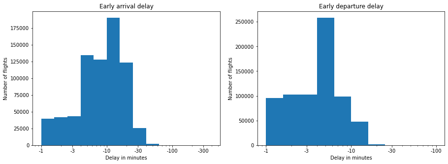

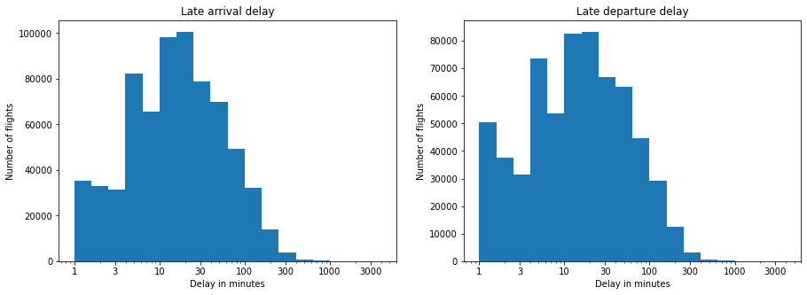

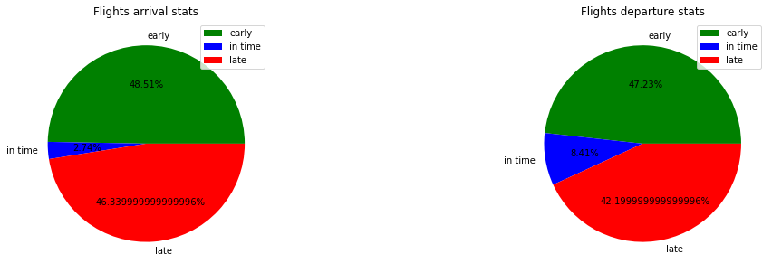

## Flights cancellation/divertion

**Cancellation**

- Only 2.17% of the flights were cancelled

**Divertion**

- Only 0.23% of the flights were diverted

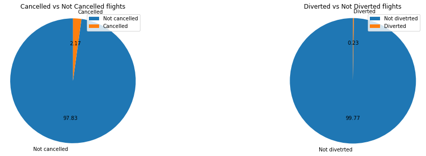

## Air Carriers flights domination

Southwest Airlines dominates the market, where it covers 16% of it, x2 ahead from its best competitor which is The American Airlines. where AQ (Aloha Airlines) seems to be a small/new carrier.

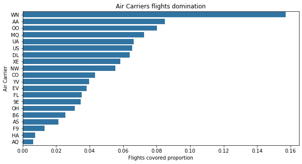

## Air Carriers cancellation reasons

Almost all carriers cancel their flights for two main reasons : Carrier issues and weather conditions, where cancellations because of NAS (National Aviation System). cancellation because of security reasons rarely happens.

[interactive chart not shown]

## Air Carriers flights delay per distance

I noticed that there isn't really a relationship between the distance and the delay, where this latter depends on the carrier, in other words how the carrier planes and stuff deal with long/medium/short distances. Where carriers such as EV and B6 always suffer from long delays during its flights (mean of 18-19min per flight) whether the long or short which indicates that these carriers are having problems managing their flights, there carriers are considered the worst carriers in matter of delay time.

however carriers such as HA and AQ often handle short distance flights (max 600 miles long ) where these carriers makes sure that their flights aways take off and arrive in time. These carriers are happen to be the best choice for short distance flights where they're doing a good job handeling short distance flights.

For the rest of the carriers we can see that each carrier handle a perticular type of flights, where some carriers usually handle long distance flights and other carriers handle short distance flights. these carriers are doing an acceptable job handling and managing their flights (mean delay time per flight is 12-16 min)

[interactive chart not shown]